# Elias Gjedde-Grundtvig

**Email:** egrundtvig@gmail.com • **GitHub:** github.com/eliiasg • **Portfolio:** eliiasg.github.io

## Summary

Software developer with experience building graphics applications and a compiler (mostly in Rust). Main interests are: Game engine development and ECS patterns, programming language development, and hardware / embedded development.  
Got **bronze** at **Baltic Olympiad in Informatics (BOI) 2026** as the only medalist on the Danish team, **silver** at **Nordic Olympiad in Informatics (NOI) 2026**, and **Honurable Mention** at **International Olympiad in Informatics (IOI) 2026**.

## Skills

- **Languages:** Rust, C#, Java, Go, C++, Python
- **Frameworks / Engines:** WGPU, OpenGL, WebGL, Godot, Bevy, MonoGame
- **Tools:** Git, Linux (Ubuntu), PostgreSQL
- **Concepts:** Algorithms & data structures, Graphics programming, ECS patterns, Parsing, Syntax Trees, Expression evaluation, Software architecture

## Projects

### Markmath — [Repo](https://github.com/EliiasG/markmath)

**Summary:** A calculator for Markdown. Parses expressions that are both evaluated and formatted as LaTeX

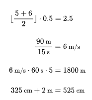

**Tech:** Rust, Pandoc  
**Highlights:**

- Developed a compiler architecture from scratch
- Invented a system to cleanly handle physical units
- Designed an abstract architecture to easily allow extending the compiler

### Real-Time vector graphics for 2D games

Designed a 2D rendering workflow using GPU-friendly triangle meshes instead of sprite-based rendering, leveraging modern GPU throughput. I explored this approach across two projects:

#### MonoGameDrawingApp — [Repo](https://github.com/EliiasG/MonoGameDrawingApp)

**Summary:** A 2D Drawing app inspired by mesh-based 3D modeling software such as Blender

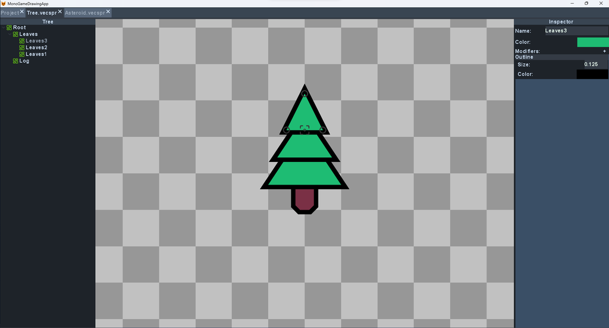

**Tech:** C#, MonoGame  
**Highlights:**

- Implemented my own UI framework on top of MonoGame
- Created a file format for efficiently storing 2D meshes
- Added a README with usage instructions and a description of the file format

#### Deltawing — [Repo](https://github.com/EliiasG/Deltawing) — [Video](https://www.youtube.com/watch?v=HjieBDv9bLg) — [Demo](https://eliiasg.github.io/flappy)

**Summary:** A 2D game engine based on mesh assets - built for customized rendering pipelines and performance

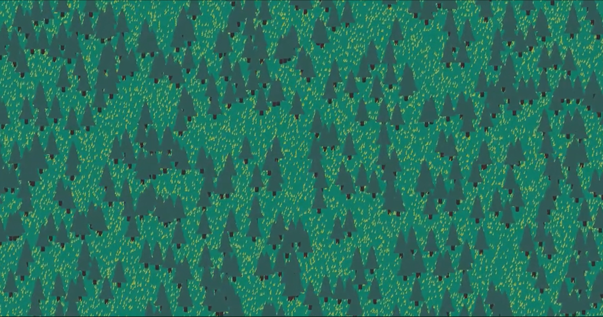

**Tech:** Go, OpenGL, WebGL  
**Highlights:**

- Implemented a rendering framework built directly on OpenGL and WebGl
- Created a platform agnostic engine, making development easy on both web and desktop platforms
- Made a file format for storing mesh fonts, and used an open-source solution to triangulate fonts

### bevy_voxel_test — [Repo](https://github.com/EliiasG/bevy_voxel_test)

**Summary:** A chunk-based voxel engine implementation on top of Bevy.

[figure not shown]

**Tech:** Rust, Bevy  
**Highlights:**

- Implemented a voxel architecture with support for LODs (levels of detail)
- Built a system for efficiently generating terrain at different LODs
- Implemented a greedy meshing algorithm to reduce triangle count

### modul — [Repo](https://github.com/EliiasG/modul)

**Summary:** A game engine based on bevy_ecs (entity component system). Aims to provide a highly modular rendering system

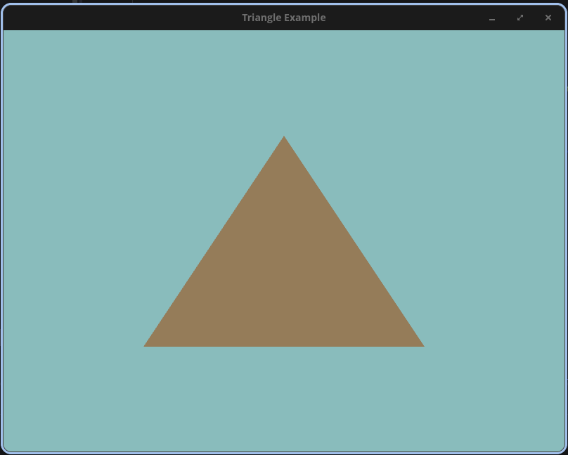

**Tech:** Rust, wgpu, bevy_ecs, winit  
**Highlights:**

- Created an asset system for managing CPU and GPU resources
- Made abstractions on top of wgpu and winit to allow for easier control over windows, textures and render pipelines
- Added examples to document my progress

## Awards & Competitions

- **International Olympiad in Informatics (IOI) 2026** — National team member; **Honorable Mention**
- **Baltic Olympiad in Informatics (BOI) 2026** — National team member; **Bronze Medal**
- **Nordic Olympiad in Informatics (NOI) 2026** — Online; **Silver Medal**
- **Baltic Olympiad in Informatics (BOI) 2025** — National team member; **Honorable Mention**

All qualified through **Dansk Datalogi Dyst**, the Danish national informatics competition. Worked on advanced algorithmic problems under strict time constraints, strengthening my problem decomposition and optimization skills.

## Experience

**Zmart NetZero** — 2025

- Java, Python, PostgreSQL
- Built a generic database system for storing energy data from different sources

**Recommendation** *(translated from Danish)*

> During my time as CTO at Zmart NetZero, I had the pleasure of having Elias Gjedde-Grundtvig as a student assistant. He was given a handful of tasks he had no prior background for, but he dug in and always got his tasks solved.

> So even when he had no knowledge of the chosen programming language, database, or technology, he got up to speed on how it all fit together and delivered results.

> I can warmly recommend Elias, and expect that he'll be useful no matter what task he's given.

## Education

**Københavns Mediegymnasium** — Expected graduation: 2028

- Programming
- Informatics

## Hobbies

Apart from programming I also enjoy electronics, 3D-printing and CAD (computer aided design)

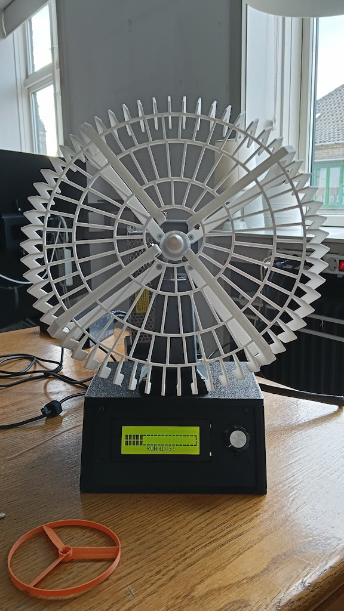

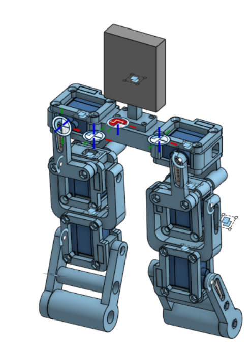

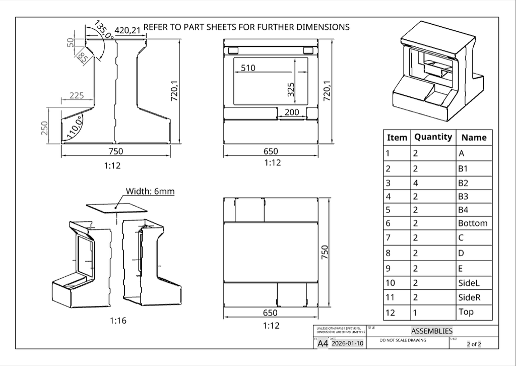